# STAT 545A Assignment 04: Tidy data and joins

Md. Belal Hossain

# Instructions

The details instructions of this assignment can be found [here](https://stat545.stat.ubc.ca/evaluation/hw04/hw04/).

# Exercise 1: Univariate Data Reshaping

## Univariate Option 1

### Task 1

*Make a tibble with one row per year, and columns for life expectancy for two or more countries.*

Before making a tibble, let us see the original dataset for two countries (Brazil and Canada) by year first. From the data table, it is clearly seen that *lifeExp* is a single variable that contains values for each year and for each country. That means this a long format dataset. To make a tibble with one row per year and columns for life expectancy for Brazil and Canada, we need to reshape this dataset from long to wide format.

```r
gapminder %>%
  filter(country %in% c("Brazil", "Canada")) %>%
  arrange(year) %>%
  DT::datatable()
```

|  | country | continent | year | lifeExp | pop | gdpPercap |
| --- | --- | --- | --- | --- | --- | --- |
| 1 | Brazil | Americas | 1952 | 50.917 | 56602560 | 2108.944355 |
| 2 | Canada | Americas | 1952 | 68.75 | 14785584 | 11367.16112 |
| 3 | Brazil | Americas | 1957 | 53.285 | 65551171 | 2487.365989 |
| 4 | Canada | Americas | 1957 | 69.96 | 17010154 | 12489.95006 |
| 5 | Brazil | Americas | 1962 | 55.665 | 76039390 | 3336.585802 |
| 6 | Canada | Americas | 1962 | 71.3 | 18985849 | 13462.48555 |
| 7 | Brazil | Americas | 1967 | 57.632 | 88049823 | 3429.864357 |
| 8 | Canada | Americas | 1967 | 72.13 | 20819767 | 16076.58803 |
| 9 | Brazil | Americas | 1972 | 59.504 | 100840058 | 4985.711467 |
| 10 | Canada | Americas | 1972 | 72.88 | 22284500 | 18970.57086 |

[output cut: 14 more lines]

The wide-format dataset is given below where the variables *Brazil* and *Canada* indicate the life expectancy values for Brazil and Canada respectively.

```r
gapminder_wide <- gapminder %>%
  filter(country %in% c("Brazil", "Canada")) %>%
  pivot_wider(id_cols = year,
              names_from = country,
              values_from = lifeExp)
  DT::datatable(gapminder_wide)
```

|  | year | Brazil | Canada |
| --- | --- | --- | --- |
| 1 | 1952 | 50.917 | 68.75 |
| 2 | 1957 | 53.285 | 69.96 |
| 3 | 1962 | 55.665 | 71.3 |
| 4 | 1967 | 57.632 | 72.13 |
| 5 | 1972 | 59.504 | 72.88 |
| 6 | 1977 | 61.489 | 74.21 |
| 7 | 1982 | 63.336 | 75.76 |
| 8 | 1987 | 65.205 | 76.86 |
| 9 | 1992 | 67.057 | 77.95 |
| 10 | 1997 | 69.388 | 78.61 |

[output cut: 2 more lines]

### Task 2

*Take advantage of this new data shape to scatterplot life expectancy for one country against that of another.*

As life expectancy values for Brazil and Canada are now in two columns, we can easily construct a scatter plot. In this case, Brazil plotted along the x-axis and Canada plotted along the y-axis. The plot is given below:

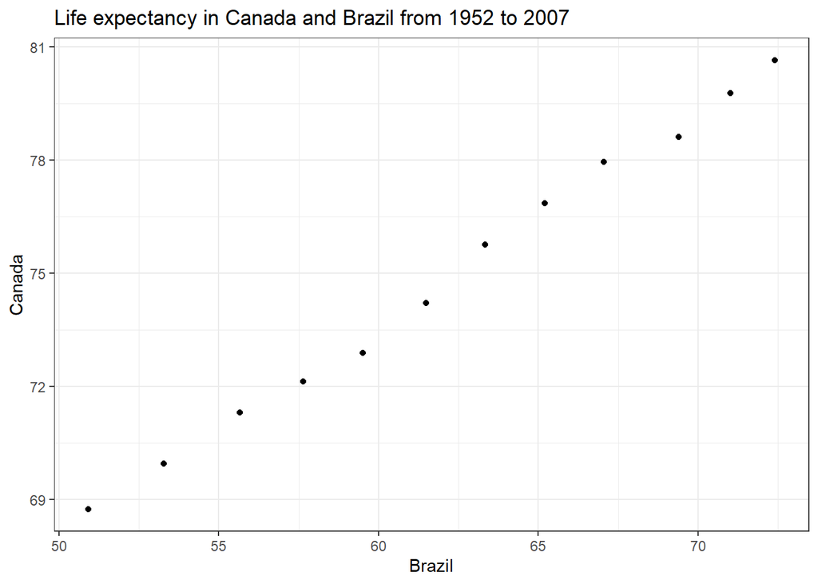

```r
gapminder_wide %>%
  ggplot() +
  geom_point(aes(x = Brazil, y = Canada)) +
  ylab("Canada")+
  xlab("Brazil") +
  ggtitle("Life expectancy in Canada and Brazil from 1952 to 2007 ") +
  theme_bw()
```

### Task 3

*Re-lengthen the data.*

To re-lengthen the data, we will change the format from wide to long. The long format dataset for the countries Brazil and Canada is given below:

```r
gapminder_long <- gapminder_wide %>%
  pivot_longer(cols = c(Brazil, Canada),
               names_to = "country",
               values_to = "LifeExp") %>%
  arrange(country)
  DT::datatable(gapminder_long)
```

|  | year | country | LifeExp |
| --- | --- | --- | --- |
| 1 | 1952 | Brazil | 50.917 |
| 2 | 1957 | Brazil | 53.285 |
| 3 | 1962 | Brazil | 55.665 |
| 4 | 1967 | Brazil | 57.632 |
| 5 | 1972 | Brazil | 59.504 |
| 6 | 1977 | Brazil | 61.489 |
| 7 | 1982 | Brazil | 63.336 |
| 8 | 1987 | Brazil | 65.205 |
| 9 | 1992 | Brazil | 67.057 |
| 10 | 1997 | Brazil | 69.388 |

[output cut: 14 more lines]

# Exercise 2: Multivariate Data Reshaping

## Multivariate Option 2

### Task 1

*Make a tibble with one row per year, and columns for life expectancy and GDP per capita (or two other numeric variables) for two or more countries.*

The wide-format dataset is given below, which contains a tibble with one row per year, and columns for life expectancy and GDP per capita for two countries Brazil and Canada. The variables *lifeExp_Brazil* and *lifeExp_Canada* indicate life expectancy, while *gdpPercap_Brazil* and *gdpPercap_Canada* indicate GDP per capita, for Brazil and Canada respectively.

```r
gapminder_wider_mv <- gapminder %>%
  filter(country %in% c("Brazil", "Canada")) %>%
  pivot_wider(id_cols = year,
              names_from = country,
              values_from = c(lifeExp, gdpPercap))
   DT::datatable(gapminder_wider_mv)
```

|  | year | lifeExp_Brazil | lifeExp_Canada | gdpPercap_Brazil | gdpPercap_Canada |
| --- | --- | --- | --- | --- | --- |
| 1 | 1952 | 50.917 | 68.75 | 2108.944355 | 11367.16112 |
| 2 | 1957 | 53.285 | 69.96 | 2487.365989 | 12489.95006 |
| 3 | 1962 | 55.665 | 71.3 | 3336.585802 | 13462.48555 |
| 4 | 1967 | 57.632 | 72.13 | 3429.864357 | 16076.58803 |
| 5 | 1972 | 59.504 | 72.88 | 4985.711467 | 18970.57086 |
| 6 | 1977 | 61.489 | 74.21 | 6660.118654 | 22090.88306 |
| 7 | 1982 | 63.336 | 75.76 | 7030.835878 | 22898.79214 |
| 8 | 1987 | 65.205 | 76.86 | 7807.095818 | 26626.51503 |
| 9 | 1992 | 67.057 | 77.95 | 6950.283021 | 26342.88426 |
| 10 | 1997 | 69.388 | 78.61 | 7957.980824 | 28954.92589 |

[output cut: 2 more lines]

### Task 2

*Re-lengthen the data.*

To re-lengthen the data, we will change the format from wide to long. The long format dataset for the countries Brazil and Canada is given below:

```r
gapminder_long_mv <- gapminder_wider_mv %>%
  pivot_longer(cols = -year,
               names_to = c(".value", "country"),
               names_sep = "_") %>%
  arrange(country)
  DT::datatable(gapminder_long_mv)
```

|  | year | country | lifeExp | gdpPercap |
| --- | --- | --- | --- | --- |
| 1 | 1952 | Brazil | 50.917 | 2108.944355 |
| 2 | 1957 | Brazil | 53.285 | 2487.365989 |
| 3 | 1962 | Brazil | 55.665 | 3336.585802 |
| 4 | 1967 | Brazil | 57.632 | 3429.864357 |
| 5 | 1972 | Brazil | 59.504 | 4985.711467 |
| 6 | 1977 | Brazil | 61.489 | 6660.118654 |
| 7 | 1982 | Brazil | 63.336 | 7030.835878 |
| 8 | 1987 | Brazil | 65.205 | 7807.095818 |
| 9 | 1992 | Brazil | 67.057 | 6950.283021 |
| 10 | 1997 | Brazil | 69.388 | 7957.980824 |

[output cut: 14 more lines]

# Exercise 3: Table Joins

*Read in the made-up wedding guestlist and email addresses. Then, complete the following tasks using the tidyverse (tidyr, dplyr, …). No need to do any pivoting – feel free to leave guest in its current format.*

## Read data

To complete Exercise 3, let us read the data first:

```r
guest <- read_csv("https://raw.githubusercontent.com/STAT545-UBC/Classroom/master/data/wedding/attend.csv")
email <- read_csv("https://raw.githubusercontent.com/STAT545-UBC/Classroom/master/data/wedding/emails.csv")
```

## Task 3.1

*For each guest in the guestlist (guest tibble), add a column for email address, which can be found in the email tibble.*

The guest variable of the email dataset contains observations with the guest’s name and their email address. Therefore, we will use ‘separate_rows’ to make two variables: one for name and another for the email address. Now, we will join the guest and email dataset together to make a guest tibble which contains the information of guests and their email addresses. The result is shown below:

```r
email.new <- email %>%
  separate_rows(guest, sep = ", ") %>%
  rename(name = guest)

  guest.new <- guest %>%
  left_join(email.new, by = "name")
  DT::datatable(guest.new)
```

|  | party | name | meal_wedding | meal_brunch | attendance_wedding | attendance_brunch | attendance_golf | email |
| --- | --- | --- | --- | --- | --- | --- | --- | --- |
| 1 | 1 | Sommer Medrano | PENDING | PENDING | PENDING | PENDING | PENDING | sommm@gmail.com |
| 2 | 1 | Phillip Medrano | vegetarian | Menu C | CONFIRMED | CONFIRMED | CONFIRMED | sommm@gmail.com |
| 3 | 1 | Blanka Medrano | chicken | Menu A | CONFIRMED | CONFIRMED | CONFIRMED | sommm@gmail.com |
| 4 | 1 | Emaan Medrano | PENDING | PENDING | PENDING | PENDING | PENDING | sommm@gmail.com |
| 5 | 2 | Blair Park | chicken | Menu C | CONFIRMED | CONFIRMED | CONFIRMED | bpark@gmail.com |
| 6 | 2 | Nigel Webb |  |  | CANCELLED | CANCELLED | CANCELLED | bpark@gmail.com |
| 7 | 3 | Sinead English | PENDING | PENDING | PENDING | PENDING | PENDING | singlish@hotmail.ca |
| 8 | 4 | Ayra Marks | vegetarian | Menu B | PENDING | PENDING | PENDING | marksa42@gmail.com |
| 9 | 5 | Atlanta Connolly | PENDING | PENDING | PENDING | PENDING | PENDING |  |
| 10 | 5 | Denzel Connolly | fish | Menu B | CONFIRMED | CONFIRMED | CONFIRMED |  |

[output cut: 20 more lines]

## Task 3.2

*Who do we have emails for, yet are not on the guestlist?*

```r
email.new %>%
  anti_join(guest, by = "name") %>%
  as_tibble() %>%
  knitr::kable() %>%
  kable_styling(latex_options = "scale_down")
```

| name | email |
| --- | --- |
| Turner Jones | tjjones12@hotmail.ca |
| Albert Marshall | themarshallfamily1234@gmail.com |
| Vivian Marshall | themarshallfamily1234@gmail.com |

Three people named Turner Jones, Albert Marshall, and Vivian Marshall have email addresses, yet they are not on the guestlist.

## Task 3.3

*Make a guestlist that includes everyone we have emails for (in addition to those on the original guestlist).*

The guest list that includes everyone (original list addition to having email) is shown below:

```r
guest %>%
  full_join(email.new, by = "name") %>%
  DT::datatable()
```

|  | party | name | meal_wedding | meal_brunch | attendance_wedding | attendance_brunch | attendance_golf | email |
| --- | --- | --- | --- | --- | --- | --- | --- | --- |
| 1 | 1 | Sommer Medrano | PENDING | PENDING | PENDING | PENDING | PENDING | sommm@gmail.com |
| 2 | 1 | Phillip Medrano | vegetarian | Menu C | CONFIRMED | CONFIRMED | CONFIRMED | sommm@gmail.com |
| 3 | 1 | Blanka Medrano | chicken | Menu A | CONFIRMED | CONFIRMED | CONFIRMED | sommm@gmail.com |
| 4 | 1 | Emaan Medrano | PENDING | PENDING | PENDING | PENDING | PENDING | sommm@gmail.com |
| 5 | 2 | Blair Park | chicken | Menu C | CONFIRMED | CONFIRMED | CONFIRMED | bpark@gmail.com |
| 6 | 2 | Nigel Webb |  |  | CANCELLED | CANCELLED | CANCELLED | bpark@gmail.com |
| 7 | 3 | Sinead English | PENDING | PENDING | PENDING | PENDING | PENDING | singlish@hotmail.ca |
| 8 | 4 | Ayra Marks | vegetarian | Menu B | PENDING | PENDING | PENDING | marksa42@gmail.com |
| 9 | 5 | Atlanta Connolly | PENDING | PENDING | PENDING | PENDING | PENDING |  |
| 10 | 5 | Denzel Connolly | fish | Menu B | CONFIRMED | CONFIRMED | CONFIRMED |  |

[output cut: 23 more lines]